# 2015-Zanconato (ChIp-seq): : Upstream analysis from fastq to peak

[Krittiyabhorn (Namthip) Kongtanawanich](https://kuchikinamthip.github.io/)

2025-01-15

# Overview of ChIP-seq analysis (both up & down stream)

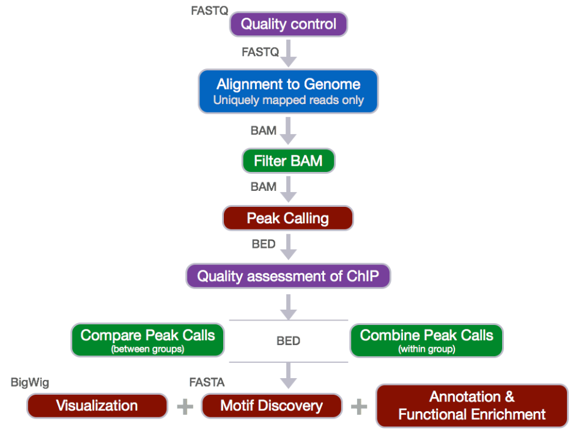

Overview of all ChIP-seq analysis. [Credit pic: Harvard Chan Bioinformatics Core](https://github.com/hbctraining/Intro-to-ChIPseq)

## Overview of upstream analysis

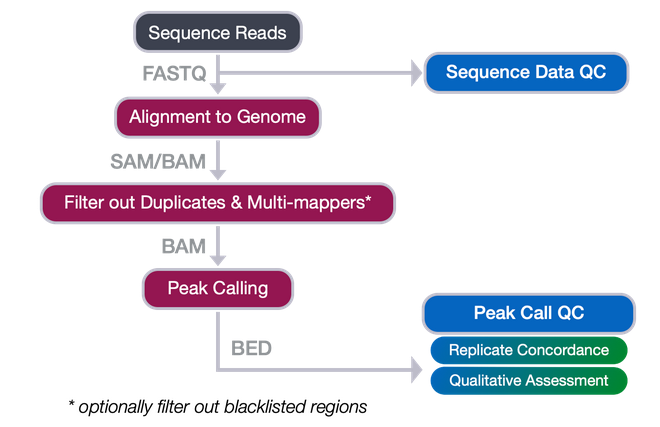

Overview of ChIP-seq upstream analysis. [Credit pic: Harvard Chan Bioinformatics Core](https://github.com/hbctraining/Intro-to-ChIPseq)

### Each step of upstream analysis

1. QC
   - input: `.fastq`
   - process: FastQC
   - output: `.fastqc`
2. Trimming adapter
   - input: `.fastq`
   - process: cutadater
   - output: `.fastq` (trimmed)
3. QC after trimming
4. Align
   - input: `.fastq` (trimmed)
   - other inputs: Bowtie reference genome index (built with `bowtie2-build reference.fa reference_index`) reference genome (fasta) and pre-build index by the aligner (explore [bowtie website](https://bowtie-bio.sourceforge.net/bowtie2/index.shtml) or nf-core/references).
   - process: bowtie2 (other option: bwa)
   - output: `.sam`
5. convert `.sam` to `.bam` file
   - input: `.sam`
   - process: samtools view
   - output: `.bam`
6. sort the reads in the bam file by coordinates
   - input: `.bam`
   - process: samtools sort
   - output: `sorted.bam`
7. index the bam file
   - input: `sorted.bam` (it is `.bam`)
   - process: samtools index
   - output: sorted.index.bam (`bam.bai`–> it is `.bam`) –> this can use for visualization in IGenome browsers like [IGV](https://igv.org/doc/webapp/) or UCSC Genome Browser
8. generate bigwig files
   - input: sorted.index.bam (`bam.bai`)
   - process: bamCoverage ([deeptools](https://deeptools.readthedocs.io/en/develop/content/list_of_tools.html)’s sub-command)
   - note:
     - `--normalizeUsing RPKM` RPKM: reads per kilobase per million reads. The formula is: RPKM (per bin) = number of reads per bin /(number of mapped reads (in millions) * bin length (kp))
     - `--extendReads 200` We only sequenced 50bp of the DNA after antibody pull-down, but the real DNA is about 200 bp (the size of the DNA after sonication/fragmentation)
   - output: .bw –> this can use for visualization in [IGV](https://igv.org/doc/webapp/)
9. peak calling
   - process: [MACS3](https://macs3-project.github.io/MACS/index.html)
   - note:
     - `–extend-size`: Extends reads to the specified fragment size (e.g., 200 bp). This mimics the actual fragment length in the absence of paired-end information.
     - `-no-model` (about model): Model building is used because the fragment size is not directly available from single-end reads. MACS shifts the reads by half the estimated fragment size to align them to the putative binding sites. BUT for paired-end data, the fragment size is directly available from the paired-end read alignment. So, use `-no-model` if you already know the approximate fragment size from your library preparation.
     - `-g hs`: the mappable genome size or effective genome size which is defined as the genome size which can be sequenced. The default hs ~2.9e9 is recommended for human genome.

### Best Practices for Peak Calling

#### Single-End Data

OPTION 1: With Model Building (Default Behavior): Let MACS build the model unless there are specific reasons to disable it.

```bash
macs2 callpeak -t treatment.bam -c control.bam -f BED -g hs -n sample –outdir results
```

OPTION 2: Without Model Building (–no-model): Use when: You know the fragment size (e.g., from library preparation or empirical testing). The library is not suitable for accurate model building (e.g., very low read depth or noisy data). Specify –extend-size to set the fragment size.

```bash
macs2 callpeak -t treatment.bam -c control.bam -f BED -g hs -n sample --outdir results --no-model --extend-size 200
```

#### Paired-End Data

`--no-model` and `--extend-size` are not needed.  
For paired-end data, model building is typically unnecessary since the fragment size is directly calculated.

#### Output files of `macs3`

1. `.narrowPeak` or `.broadPeak`: These files contain the genomic coordinates of the called peaks, along with other relevant information such as peak summit, p-value, and fold enrichment. This file is like a map showing the general territory where your protein of interest is hanging out. It outlines the entire region of enrichment, including the summit and the surrounding areas where the protein might be bound with slightly lower affinity.
- Narrow peaks = TF
- Broad peaks = histone modifiers
2. `.xls` or `.csv`: These files provide a more human-readable summary of the peak information, including peak location, length, and statistical significance.
3. `.bedGraph`: This file contains a continuous signal track of the ChIP-seq enrichment across the genome.
4. `_summits.bed`: This file contains the genomic coordinates of the peak summits, which represent the most likely binding sites of the protein of interest. This file is like a pinpoint on the map, marking the exact spot where your protein is most likely to be camped out. It represents the point of highest enrichment within the peak, indicating the most probable binding site.

So, the `.narrowPeak` or `.broadPeak` file gives you the broader picture of the protein-DNA interaction, while the `_summit.bed` file zooms in on the most critical binding location.

# Perform upstream analysis

## 1. Downloading `fastq` files from GEO

By using nf-core `fetchngs` pipeline, the default (`FTP`) will be used.

[figure not shown]

Overview of `fetchngs` from nf-core (nf-core/fetchngs) [Credit pic](https://nf-co.re/fetchngs/1.12.0/)

To download those mentioned fastq files, we have to create a file named `ids.csv` where contains all `SRR` numbers that we want to download.

```bash
# Go to directory where `ids.csv` file was saved
cd data/fetchngs

# Oberving the `ids.csv` file
cat ids.csv
```

This is `ids.csv` file

```bash
    SRR1810907
    SRR1810900
    SRR1810918
    SRR1810912
```

Next, I define the needed information in [nf-core/fetchngs launch pipeline](https://oldsite.nf-co.re/launch?id=1725856723_087226f05d65). After launch the workflow, I got `nf-params.json` file. I download the file to run it locally.

Here is my `nf-params.json`. Please note that we will run all process on High Performance Computing (HPC), thus the file paths are full path of HPC.

```bash
# Go to directory where the `nf-params.json file was saved
cd data/HPC/data/fetchngs

# Observing the `nf-params.json` file
cat nf-params.json
```

This is `nf-params.json` file

```bash
    {
        "input": "/mnt/sisplockers/krittiyabhornk/nf/ChIP_Chatomic/data/ids.csv",
        "outdir": "/mnt/sisplockers/krittiyabhornk/nf/ChIP_Chatomic/data",
        "email": "kkrittiyabhorn@gmail.com"
    }
```

```bash
nextflow run nf-core/fetchngs -r 1.12.0 -name Zanconato -params-file nf-params.json -profile docker
```

After pipeline finished successfully, we will find these 4 fastq files.

## 2. Reference genome and genome annotation

As I mentioned above that aligning on reference genome. We will use reference genome that provided by nf-core which we will use human `GRCh38`.

## 3. Performing upstream analysis

The upstream analysis was performed on HPC using a nf-core pipeline called `chipseq`.

[figure not shown]

From `nf-core/chipseq` pipeline, we will mainly use the blue pipeline where `BWA` will be used for aligning. I will use `Bowties2` for aligning, thus my pipeline will be the yellow line

To analyze a set of `.fastq` files, we have to create a file named `samplesheet.csv` where includes all information about our `.fastq` file.

In my case, my data is single-end sequencing read. Thus, I have only one fastq file per each replicate of each sample.

```bash
# Go to directory that save `samplesheet.csv` file
cd data/chipseq

# Observing the `samplesheet.csv` file
cat samplesheet.csv
```

```bash
    sample,fastq_1,fastq_2,replicate,antibody,control,control_replicate
    YAP,/mnt/sisplockers/krittiyabhornk/nf/ChIP_Chatomic/data/fastq/SRX883578_SRR1810907.fastq.gz,,1,YAP,IgG,1
    TAZ,/mnt/sisplockers/krittiyabhornk/nf/ChIP_Chatomic/data/fastq/SRX883576_SRR1810900.fastq.gz,,1,TAZ,IgG,1
    TEAD4,/mnt/sisplockers/krittiyabhornk/nf/ChIP_Chatomic/data/fastq/SRX883582_SRR1810918.fastq.gz,,1,TEAD4,IgG,1
    IgG,/mnt/sisplockers/krittiyabhornk/nf/ChIP_Chatomic/data/fastq/SRX883580_SRR1810912.fastq.gz,,1,,,
```

Next, I define the needed information in [nf-core/chipseq launch pipeline](https://oldsite.nf-co.re/launch?id=1736947172_92a169decca6). After launch the workflow, I got `nf-params.json` file. I download the file to run the analysis it locally.

Please note that  
- we will run all process on High Performance Computing (HPC), thus the file paths are full path of HPC.  
- Since we use nf-core provided reference genome, the black-listed regions will be automatically excluded by the pipeline (They have provided black-listed regions.)

Here is my `nf-params.json`.

```bash
# Go to directory where the `nf-params.json file was saved
cd data/chipseq

# Observing the `nf-params.json` file
cat nf-params.json
```

```bash
   {
        "input": "\/mnt\/sisplockers\/krittiyabhornk\/nf\/ChIP_Chatomic\/samplesheet.csv",
        "outdir": "\/mnt\/sisplockers\/krittiyabhornk\/nf\/ChIP_Chatomic\/output_new",
        "genome": "GRCh38",
        "aligner": "bowtie2",
        "narrow_peak": true,
        "macs_gsize": 2701495711
   }
```

NOTE: `macs_gsize` for `macs3` software is defined according to read length = 50 bp (This is known from library preparation.). However, normally we can used default values for [each version human genome as showed by deeptools](https://deeptools.readthedocs.io/en/develop/content/feature/effectiveGenomeSize.html#effective-genome-size). You can used `macs3 callpeak -g hs` if you are not using nf-core (hs: 2,913,022,398 for GRCh38).

```bash
nextflow run nf-core/chipseq -r 2.1.0 -name Chatomic4 -profile docker -resume -params-file nf-params.json
```

The process will start and show the picture below. Moreover, it will real-time update the status of each process.

[figure not shown]

After the analysis complete, the command will show as picture below.

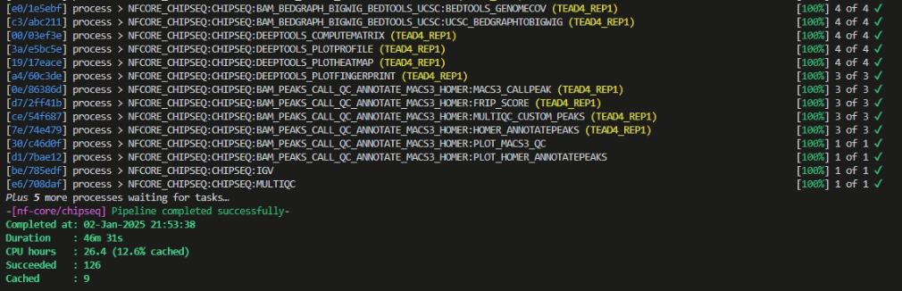

Please note that we can close our terminal by using `screen` command [(see my trick)](https://kuchikinamthip.github.io/blog/2024/CompUnix1_Screen/).

We can observe QC from both pre and post-alignment and many more visualization created by the tools provided by `nf-core/chipseq` pipeline from [`MultiQC.html`](https://kuchikinamthip.github.io/ComBio_Portfolio/Epigenome_ChIP-seq/2015-Zanconato/ChIP_multiqc_report.html) file.

[figure not shown]

MultiQc file

### Visualize the peak

We can visualize peak (`narrowPeak.bed` and `_summit.bed`) and the normalized fragment the mapped to the reference genome (`.bigWig`) using [Integrative Genomics Viewer(IGV)](https://igv.org/) which currently have web app. You can see your data without IGV software installation.

[figure not shown]

Visualize the peak using IGV-web app